# Tidy Verse

Monu Chacko

5/4/2019

#### Data

```r
library(tidyr)
library(dplyr)
library(tidyverse)
library(janitor)
library(kableExtra)
```

```r
dsWBB <- read.csv("https://raw.githubusercontent.com/fivethirtyeight/data/master/ncaa-womens-basketball-tournament/ncaa-womens-basketball-tournament-history.csv", sep = ",", stringsAsFactors = F)
```

#### View raw data

```r
head(dsWBB) %>% kable() %>% kable_styling()
```

ï..Year

School

Seed

Conference

Conf..W

Conf..L

Conf…

Conf..place

Reg..W

Reg..L

Reg…

How.qual

X1st.game.at.home.

Tourney.W

Tourney.L

Tourney.finish

Full.W

Full.L

Full..

1982

Arizona St.

4

Western Collegiate

23

6

79.3

at-large

Y

1

1

RSF

24

7

77.4

1982

Auburn

7

Southeastern

24

4

85.7

at-large

N

0

1

1st

24

5

82.8

1982

Cheyney

2

Independent

24

2

92.3

at-large

Y

4

1

N2nd

28

3

90.3

1982

Clemson

5

Atlantic Coast

6

3

66.7

4th

20

11

64.5

at-large

N

0

1

1st

20

12

62.5

1982

Drake

4

Missouri Valley

26

6

81.3

auto

Y

2

1

RF

28

7

80

1982

East Carolina

6

Independent

19

7

73.1

at-large

N

0

1

1st

19

8

70.4

```r
# Check columns
colnames(dsWBB)
```

```
##  [1] "ï..Year"            "School"             "Seed"
##  [4] "Conference"         "Conf..W"            "Conf..L"
##  [7] "Conf..."            "Conf..place"        "Reg..W"
## [10] "Reg..L"             "Reg..."             "How.qual"
## [13] "X1st.game.at.home." "Tourney.W"          "Tourney.L"
## [16] "Tourney.finish"     "Full.W"             "Full.L"
## [19] "Full.."
```

#### Rename columns and view data

```r
# Rename columns
names(dsWBB) <- c("Year", "School", "Seed", "Conference", "ConfW", "ConfL","Conf", "ConfPlace", "RegW", "RegL", "Reg", "HowQual", "X1stGameAtHome", "TourneyW", "TourneyL", "TourneyFinish", "FullW", "FullL", "Full")

# Vew data
head(dsWBB) %>% kable() %>% kable_styling()
```

Year

School

Seed

Conference

ConfW

ConfL

Conf

ConfPlace

RegW

RegL

Reg

HowQual

X1stGameAtHome

TourneyW

TourneyL

TourneyFinish

FullW

FullL

Full

1982

Arizona St.

4

Western Collegiate

23

6

79.3

at-large

Y

1

1

RSF

24

7

77.4

1982

Auburn

7

Southeastern

24

4

85.7

at-large

N

0

1

1st

24

5

82.8

1982

Cheyney

2

Independent

24

2

92.3

at-large

Y

4

1

N2nd

28

3

90.3

1982

Clemson

5

Atlantic Coast

6

3

66.7

4th

20

11

64.5

at-large

N

0

1

1st

20

12

62.5

1982

Drake

4

Missouri Valley

26

6

81.3

auto

Y

2

1

RF

28

7

80

1982

East Carolina

6

Independent

19

7

73.1

at-large

N

0

1

1st

19

8

70.4

#### Drop columns that are not used and view data

```r
# Drop columns that are not necessary
dsWBB_new <- select(dsWBB, "Year", "Seed", "Conference", "HowQual", "X1stGameAtHome", "TourneyW", "TourneyL", "TourneyFinish", "FullW", "FullL", "Full")

# View new data
head(dsWBB_new) %>% kable() %>% kable_styling()
```

| Year | Seed | Conference | HowQual | X1stGameAtHome | TourneyW | TourneyL | TourneyFinish | FullW | FullL | Full |
| --- | --- | --- | --- | --- | --- | --- | --- | --- | --- | --- |
| 1982 | 4 | Western Collegiate | at-large | Y | 1 | 1 | RSF | 24 | 7 | 77.4 |
| 1982 | 7 | Southeastern | at-large | N | 0 | 1 | 1st | 24 | 5 | 82.8 |
| 1982 | 2 | Independent | at-large | Y | 4 | 1 | N2nd | 28 | 3 | 90.3 |
| 1982 | 5 | Atlantic Coast | at-large | N | 0 | 1 | 1st | 20 | 12 | 62.5 |
| 1982 | 4 | Missouri Valley | auto | Y | 2 | 1 | RF | 28 | 7 | 80 |
| 1982 | 6 | Independent | at-large | N | 0 | 1 | 1st | 19 | 8 | 70.4 |

#### Extract and other data operations

```r
# Create new column from existing columns
dsWBB_new <- mutate(dsWBB_new, FullWToLRatio = round(dsWBB_new$FullW/dsWBB_new$FullL))

# Filter for year 1982
dsWBB_new_1982 <- filter(dsWBB_new, Year == "1982")

# View new data for 1982
head(dsWBB_new_1982) %>% kable() %>% kable_styling()
```

| Year | Seed | Conference | HowQual | X1stGameAtHome | TourneyW | TourneyL | TourneyFinish | FullW | FullL | Full | FullWToLRatio |
| --- | --- | --- | --- | --- | --- | --- | --- | --- | --- | --- | --- |
| 1982 | 4 | Western Collegiate | at-large | Y | 1 | 1 | RSF | 24 | 7 | 77.4 | 3 |
| 1982 | 7 | Southeastern | at-large | N | 0 | 1 | 1st | 24 | 5 | 82.8 | 5 |
| 1982 | 2 | Independent | at-large | Y | 4 | 1 | N2nd | 28 | 3 | 90.3 | 9 |
| 1982 | 5 | Atlantic Coast | at-large | N | 0 | 1 | 1st | 20 | 12 | 62.5 | 2 |
| 1982 | 4 | Missouri Valley | auto | Y | 2 | 1 | RF | 28 | 7 | 80 | 4 |
| 1982 | 6 | Independent | at-large | N | 0 | 1 | 1st | 19 | 8 | 70.4 | 2 |

#### Sorting

```r
# Sort desc on FullWToLRatio
dsWBB_new_sorted <- arrange(dsWBB_new, desc(FullWToLRatio))

# Remove na
dsWBB_new_sorted$FullWToLRatio <- as.numeric(na.omit(dsWBB_new_sorted$FullWToLRatio))

# View sorted data
head(dsWBB_new_sorted) %>% kable() %>% kable_styling()
```

| Year | Seed | Conference | HowQual | X1stGameAtHome | TourneyW | TourneyL | TourneyFinish | FullW | FullL | Full | FullWToLRatio |
| --- | --- | --- | --- | --- | --- | --- | --- | --- | --- | --- | --- |
| 1986 | 1 | Southwest | auto | Y | 5 | 0 | Champ | 34 | 0 | 100 | Inf |
| 1995 | 1 | Big East | auto | Y | 6 | 0 | Champ | 35 | 0 | 100 | Inf |
| 2002 | 1 | Big East | auto | Y | 6 | 0 | Champ | 39 | 0 | 100 | Inf |
| 2009 | 1 | Big East | auto | Y | 6 | 0 | Champ | 39 | 0 | 100 | Inf |
| 2010 | 1 | Big East | auto | N | 6 | 0 | Champ | 39 | 0 | 100 | Inf |
| 2012 | 1 | Big 12 | auto | N | 6 | 0 | Champ | 40 | 0 | 100 | Inf |

#### As we see in the above data, we have a divide by 0 error in column FullWToLRatio. We can replace all FullWToLRatio data with FullW where FullL is 0

```r
#Create new calculated colum
dsWBB_new_sorted = dsWBB_new_sorted %>% mutate(FullWToLRatio = factor(ifelse(FullL == 0, FullW, FullWToLRatio)))

# View sorted data
head(dsWBB_new_sorted) %>% kable() %>% kable_styling()
```

| Year | Seed | Conference | HowQual | X1stGameAtHome | TourneyW | TourneyL | TourneyFinish | FullW | FullL | Full | FullWToLRatio |
| --- | --- | --- | --- | --- | --- | --- | --- | --- | --- | --- | --- |
| 1986 | 1 | Southwest | auto | Y | 5 | 0 | Champ | 34 | 0 | 100 | 34 |
| 1995 | 1 | Big East | auto | Y | 6 | 0 | Champ | 35 | 0 | 100 | 35 |
| 2002 | 1 | Big East | auto | Y | 6 | 0 | Champ | 39 | 0 | 100 | 39 |
| 2009 | 1 | Big East | auto | Y | 6 | 0 | Champ | 39 | 0 | 100 | 39 |
| 2010 | 1 | Big East | auto | N | 6 | 0 | Champ | 39 | 0 | 100 | 39 |
| 2012 | 1 | Big 12 | auto | N | 6 | 0 | Champ | 40 | 0 | 100 | 40 |

#### Splits and Levels

```r
# View Levels
FullWToLRatioLevels <- cut(as.numeric(dsWBB_new_sorted$FullWToLRatio), breaks = 10) %>% levels
FullWToLRatioLevels %>% kable() %>% kable_styling()
```

| x |
| --- |
| (0.971,3.9] |
| (3.9,6.8] |
| (6.8,9.7] |
| (9.7,12.6] |
| (12.6,15.5] |
| (15.5,18.4] |
| (18.4,21.3] |
| (21.3,24.2] |
| (24.2,27.1] |
| (27.1,30] |

### Summarise and visualize data

```r
# Summarise
summarise(dsWBB_new_sorted, "MeanWLRatio" = mean(as.numeric(dsWBB_new_sorted$FullWToLRatio), na.rm = TRUE), "SDWLRatio" = sd(as.numeric(dsWBB_new_sorted$FullWToLRatio), na.rm = TRUE))
```

```
##   MeanWLRatio SDWLRatio
## 1    3.970841  3.605831
```

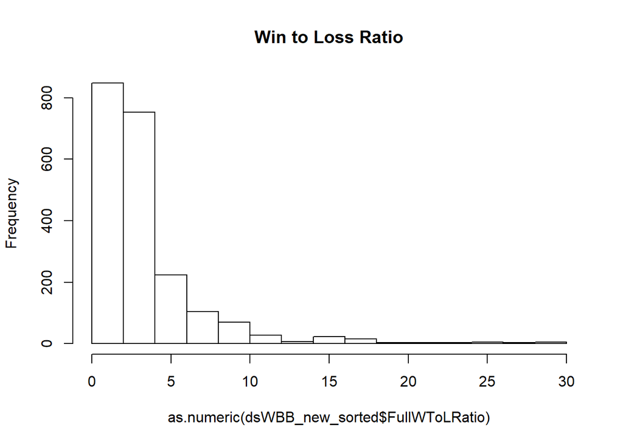

```r
# View hist
hist(x=as.numeric(dsWBB_new_sorted$FullWToLRatio), main = "Win to Loss Ratio")
```